# rsibal_FinalHomeworkCode_03

[video not shown]

*Got information about embedded video from: https://stackoverflow.com/questions/38517236/youtube-video-in-r-markdown*

## Question 1

### Calculate the population mean and standard deviation for each quantitative random variable (height, weight, age, number of zombies killed, and years of education). NOTE: You will not want to use the built in var() and sd() commands as these are for samples.

*Jess’s comments: Fun! I watched this TV series a few years back, it combines zombies and crime. What’s not to love?! I also haven’t embedded a video in an RMD file yet, but I’m definitely going to use that link to do so for the next homework assignment.*

```r
# Load in the dataset “zombies.csv”
library(readr)
zombies <- read_csv("https://raw.githubusercontent.com/fuzzyatelin/fuzzyatelin.github.io/master/AN588_Fall23/zombies.csv")
```

```r
# Create a population SD function
pop_sd <- function (data, mean) {
  sqrt(sum((data-mean)^2)/length(data))
}

(height_mean<-mean(zombies$height))
```

```
## [1] 67.6301
```

```r
(height_sd<-pop_sd(zombies$height, height_mean))
```

```
## [1] 4.30797
```

```r
(weight_mean<-mean(zombies$weight))
```

```
## [1] 143.9075
```

```r
(weight_sd<-pop_sd(zombies$weight, weight_mean))
```

```
## [1] 18.39186
```

```r
(age_mean<-mean(zombies$age))
```

```
## [1] 20.04696
```

```r
(age_sd<-pop_sd(zombies$age, age_mean))
```

```
## [1] 2.963583
```

```r
(zombies_killed_mean<-mean(zombies$zombies_killed))
```

```
## [1] 2.992
```

```r
(zombies_killed_sd<-pop_sd(zombies$zombies_killed, zombies_killed_mean))
```

```
## [1] 1.747551
```

```r
(education_yrs_mean<-mean(zombies$years_of_education))
```

```
## [1] 2.996
```

```r
(education_yrs_sd<-pop_sd(zombies$years_of_education, education_yrs_mean))
```

```
## [1] 1.675704
```

```r
# References:
# https://sebastiansauer.github.io/Download-from-Github/
# https://stackoverflow.com/questions/38418751/r-calculating-population-standard-deviation-with-na
```

## Question 2

### Use {ggplot} to make boxplots of each of these variables by gender.

*Jess’s comments: Wow, I like how you made the plotting into a function- that’s very efficient. Also, not at all necessary but maybe consider adding some color to your plots.*

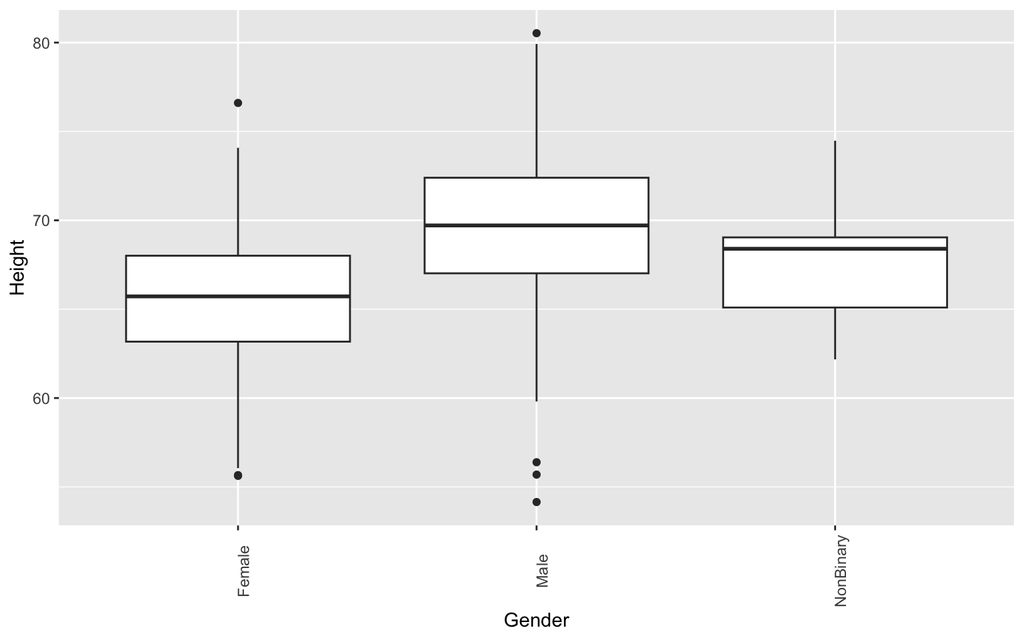

```r
library(ggplot2)
# Make a function to plot to reduce code duplication
plot_box <- function (data, x_var, y_var, x_name, y_name){
  p <- ggplot(data = zombies, aes(x = x_var, y = y_var)) #define the variables
  p <- p + geom_boxplot()  #graph them in a boxplot
  p <- p + theme(axis.text.x = element_text(angle = 90))  #put x-axis names at 90deg
  p <- p + ylab(y_name) + xlab(x_name)  #rename y-axis title
  p  #show me the graph
}

plot_box(zombies, zombies$gender, zombies$height, "Gender", "Height")
```

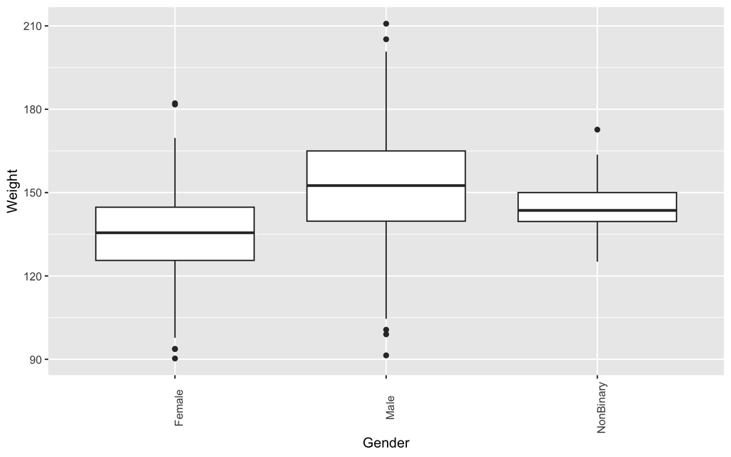

```r
plot_box(zombies, zombies$gender, zombies$weight, "Gender", "Weight")
```

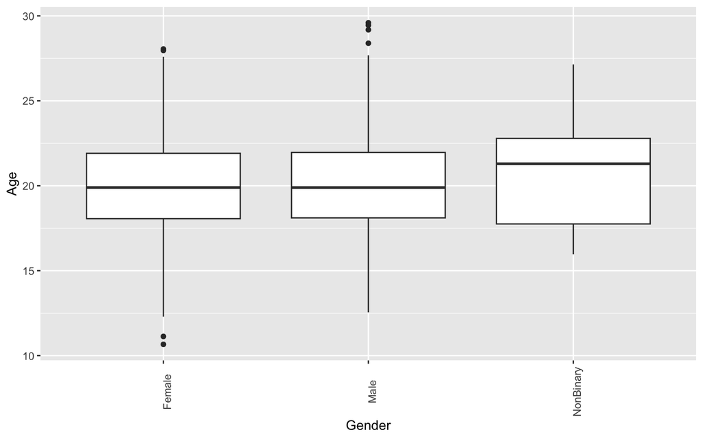

```r
plot_box(zombies, zombies$gender, zombies$age, "Gender", "Age")
```

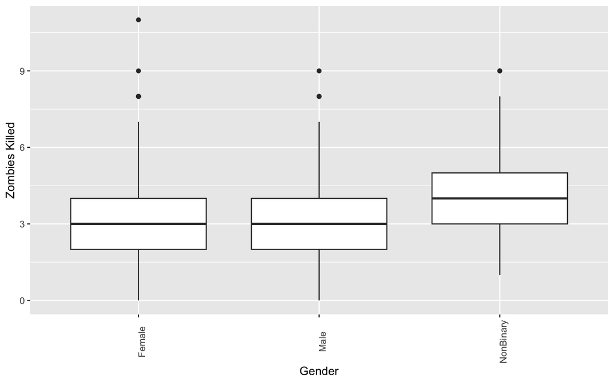

```r
plot_box(zombies, zombies$gender, zombies$zombies_killed, "Gender", "Zombies Killed")
```

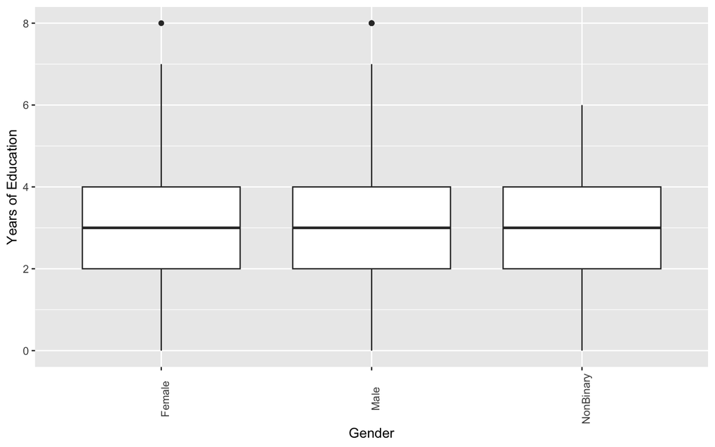

```r
plot_box(zombies, zombies$gender, zombies$years_of_education, "Gender", "Years of Education")
```

## Question 3

### Use {ggplot} to make scatterplots of height and weight in relation to age. Do these variables seem to be related? In what way?

*Jess’s comments: Excellent work! Our scatterplots and correlation findings are quite similar, which makes sense considering the variables.*

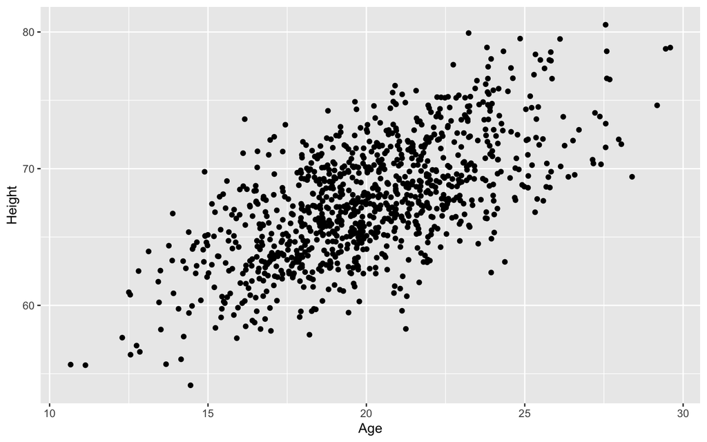

```r
p1 <- ggplot(data = zombies, aes(x = age, y = height))  # first, we build a plot object and color points by age
p1 <- p1 + xlab("Age") + ylab("Height")  # then we modify the axis labels
p1 <- p1 + geom_point()  # then we make a scatterplot
p1  # and, finally, we plot the object
```

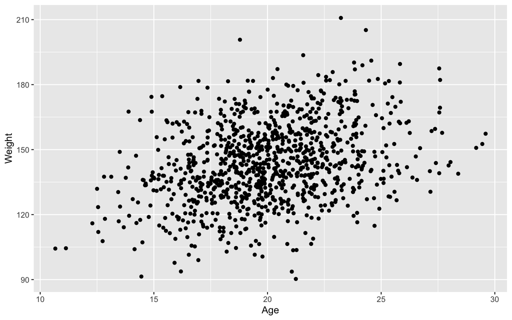

```r
p2 <- ggplot(data = zombies, aes(x = age, y = weight))  # first, we build a plot object and color points by age
p2 <- p2 + xlab("Age") + ylab("Weight")  # then we modify the axis labels
p2 <- p2 + geom_point()  # then we make a scatterplot
p2  # and, finally, we plot the object
```

```r
# References: https://stackoverflow.com/questions/1249548/side-by-side-plots-with-ggplot2
```

We see a positive correlation between age and both height and weight. As age increases, generally height and weight increase.

## Question 4

### Using histograms and Q-Q plots, check whether the quantitative variables seem to be drawn from a normal distribution. Which seem to be and which do not (hint: not all are drawn from the normal distribution)? For those that are not normal, can you determine from which common distribution they are drawn?

*Jess’s comments: You are killing this assignment! Again, our histograms/ Q-Q plots and findings are nearly identical. However, I believe the quantitative variables (zombies killed and years of education) drawn from a non-normal distribution are right skewed, not left. I also made this mistake- it is not intuitive. Also, you did not note which common distribution the non-normal variables were drawn from. I’m thinking Poisson distribution.*

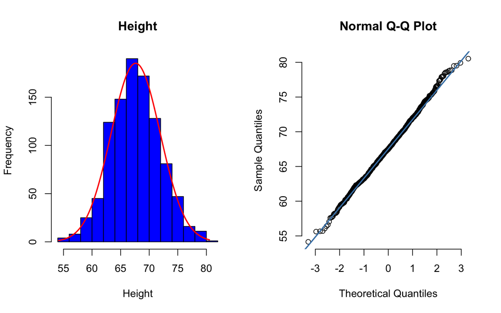

```r
# histogram plot first
plot_hist_and_norm <- function(x_var, x_name, popsd){
  p1<-hist(x_var, plot=FALSE)
  plot(p1, col='blue', xlab=x_name, ylab='Frequency', main=x_name)
  # Add a line to the histogram plot showing normal distribution
  xfit <- seq(min(x_var), max(x_var), length = length(x_var))
  yfit <- dnorm(xfit, mean = mean(x_var), sd = popsd)
  yfit <- yfit * diff(p1$mids[1:2]) * length(x_var)
  lines(xfit, yfit, col = "red", lwd = 2)
}

qq_plots <- function(data){
  qqnorm(data, pch = 1, frame = FALSE)
  # Add line to plot
  qqline(data, col = "steelblue", lwd = 2)
}

# Yes, normal dist
par(mfrow=c(1,2))
plot_hist_and_norm(zombies$height, "Height", height_sd)
qq_plots(zombies$height)
```

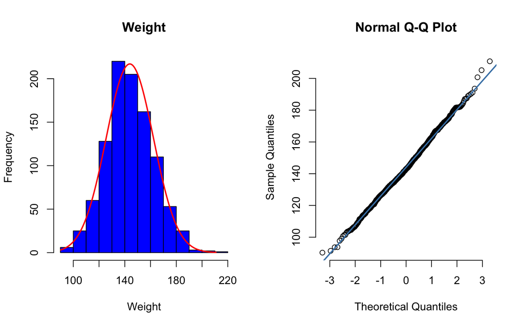

```r
# Yes, normal dist
plot_hist_and_norm(zombies$weight, "Weight", weight_sd)
qq_plots(zombies$weight)
```

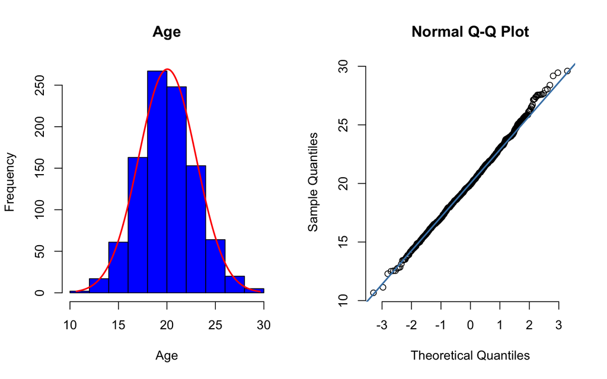

```r
# Yes, normal dist
plot_hist_and_norm(zombies$age, "Age", age_sd)
qq_plots(zombies$age)
```

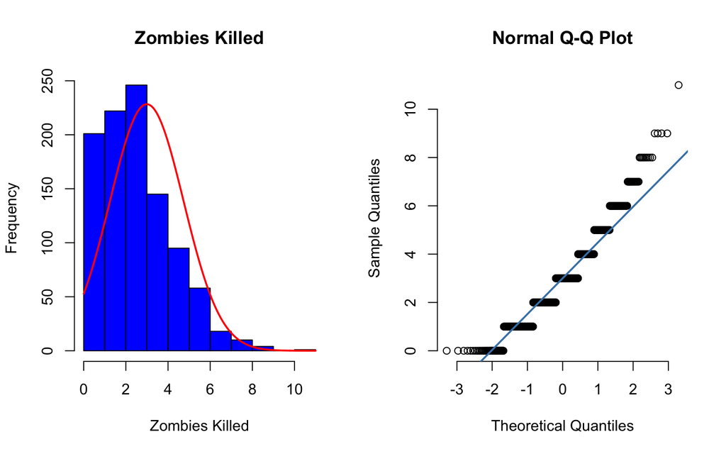

```r
# No, not normal dist. This looks like a right skewed distribution based on the convex qqnorm curve and the visual histogram. Possibly a poison distribution
plot_hist_and_norm(zombies$zombies_killed, "Zombies Killed", zombies_killed_sd)
qq_plots(zombies$zombies_killed)
```

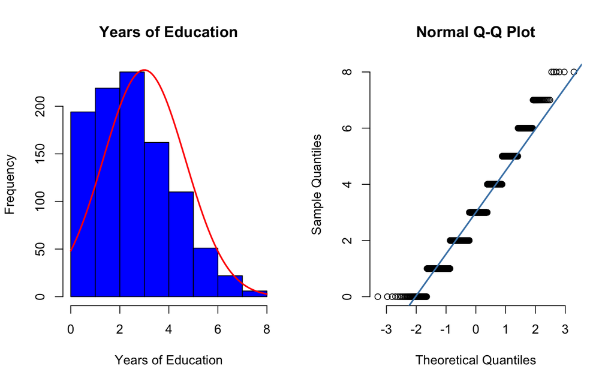

```r
# No, not normal dist. This looks like a right skewed distribution based on the convex qqnorm curve and the visual histogram. Possibly a poison distribution
plot_hist_and_norm(zombies$years_of_education, "Years of Education", education_yrs_sd)
qq_plots(zombies$years_of_education)
```

## Question 5

### Now use the sample() function to sample ONE subset of 30 zombie survivors (without replacement) from this population and calculate the mean and sample standard deviation for each variable. Also estimate the standard error for each variable, and construct the 95% confidence interval for each mean. Note that for the variables that are not drawn from the normal distribution, you may need to base your estimate of the CIs on slightly different code than for the normal…

*Jess’s comments: Your code for this question is so well-organized! I found it challenging to write my code for the variables not drawn from a normal distribution, but you made it look effortless. I will keep this in mind to improve my own code. Well done!*

```r
library(dplyr)
# This will sample by rows, giving us a data frame
sample_zombies <- slice_sample(zombies, n = 30, replace = FALSE)

# Norm calculation for distributions that are not normal (taken from Mod 9)
norm_ci_calculations <- function(mean, sd){
  sample_size=30
  (sem <- sd/sqrt(sample_size))
  lower <- mean - qnorm(1 - 0.05/2) * sem  # (1-alpha)/2 each in the upper and lower tails of the distribution
  upper <- mean + qnorm(1 - 0.05/2) * sem  # (1-alpha)/2 each in the upper and lower tails of the distribution
  ci_norm <- c(lower, upper, sem)
  ci_norm
}

# T calculation for distributions that are not normal (taken from Mod 9)
t_ci_calculations <- function(mean, sd){
  sample_size=30
  (sem <- sd/sqrt(sample_size))
  lower <- mean - qt(1 - 0.05/2, df = sample_size - 1) * sem  # (1-alpha)/2 each in the upper and lower tails of the distribution
  upper <- mean + qt(1 - 0.05/2, df = sample_size - 1) * sem  # (1-alpha)/2 each in the upper and lower tails of the distribution
  ci_t <- c(lower, upper, sem)
  ci_t
}
# Normal Distribution
(height_mean<-mean(sample_zombies$height))
```

```
## [1] 67.29806
```

```r
(height_sd<-sd(sample_zombies$height))
```

```
## [1] 3.104536
```

```r
# This will give: lower bound, upper bound and sem
(height_ci<-norm_ci_calculations(height_mean,height_sd))
```

```
## [1] 66.1871351 68.4089820  0.5668081
```

```r
(weight_mean<-mean(sample_zombies$weight))
```

```
## [1] 143.6165
```

```r
(weight_sd<-sd(sample_zombies$weight))
```

```
## [1] 15.14319
```

```r
# This will give: lower bound, upper bound and sem
(weight_ci<-norm_ci_calculations(weight_mean,weight_sd))
```

```
## [1] 138.197646 149.035285   2.764755
```

```r
(age_mean<-mean(sample_zombies$age))
```

```
## [1] 19.32624
```

```r
(age_sd<-sd(sample_zombies$age))
```

```
## [1] 2.403528
```

```r
# This will give: lower bound, upper bound and sem
(age_ci<-norm_ci_calculations(age_mean,age_sd))
```

```
## [1] 18.4661641 20.1863152  0.4388221
```

```r
# Not Normal Distribution
(zombies_killed_mean<-mean(sample_zombies$zombies_killed))
```

```
## [1] 2.933333
```

```r
(zombies_killed_sd<-sd(sample_zombies$zombies_killed))
```

```
## [1] 1.460593
```

```r
# This will give: lower bound, upper bound and sem
(zombies_killed_ci<-t_ci_calculations(zombies_killed_mean,zombies_killed_sd))
```

```
## [1] 2.3879388 3.4787279 0.2666667
```

```r
(education_yrs_mean<-mean(zombies$years_of_education))
```

```
## [1] 2.996
```

```r
(education_yrs_sd<-sd(zombies$years_of_education))
```

```
## [1] 1.676543
```

```r
# This will give: lower bound, upper bound and sem
(education_yrs_ci<-t_ci_calculations(education_yrs_mean,education_yrs_sd))
```

```
## [1] 2.3699687 3.6220313 0.3060934
```

## Question 6

### Now draw 99 more random samples of 30 zombie apocalypse survivors, and calculate the mean for each variable for each of these samples. Together with the first sample you drew, you now have a set of 100 means for each variable (each based on 30 observations), which constitutes a sampling distribution for each variable. What are the means and standard deviations of this distribution of means for each variable? How do the standard deviations of means compare to the standard errors estimated in [5]? What do these sampling distributions look like (a graph might help here)? Are they normally distributed? What about for those variables that you concluded were not originally drawn from a normal distribution?

*Jess’s comments: Cool! We used similar approaches and obtained similar results.*

```r
library(dplyr)
# Create vectors with the values calculated in Question 5 as the first value
height_means <- c(height_mean)
weight_means <- c(weight_mean)
age_means <- c(age_mean)
zombies_killed_means <- c(zombies_killed_mean)
education_yrs_means <- c(education_yrs_mean)

# For 99 more iterations
for (x in 1:99){
  # Sample 30 from the population and calculate the sample means (this samples rows)
  sample_zombies <- slice_sample(zombies, n = 30, replace = FALSE)
  # Append the calculated means into the vector
  height_means <- c(height_means, mean(sample_zombies$height))
  weight_means <- c(weight_means, mean(sample_zombies$weight))
  age_means <- c(age_means, mean(sample_zombies$age))
  zombies_killed_means <- c(zombies_killed_means, mean(sample_zombies$zombies_killed))
  education_yrs_means <- c(education_yrs_means, mean(sample_zombies$years_of_education))
}

# Calculate the Mean for all 100 sample means
(sample_height_mean <- mean(height_means))
```

```
## [1] 67.65043
```

```r
(sample_weight_mean <- mean(weight_means))
```

```
## [1] 143.8308
```

```r
(sample_age_mean <- mean(age_means))
```

```
## [1] 20.06048
```

```r
(sample_zombies_killed_mean <- mean(zombies_killed_means))
```

```
## [1] 2.921667
```

```r
(sample_education_yrs <- mean(education_yrs_means))
```

```
## [1] 2.99896
```

```r
# Calculate the SD for all 100 sample means
(height_means_sd <- sd(height_means))
```

```
## [1] 0.7163526
```

```r
(weight_means_sd <- sd(weight_means))
```

```
## [1] 3.361164
```

```r
(age_means_sd <- sd(age_means))
```

```
## [1] 0.5525942
```

```r
(zombies_killed_means_sd <- sd(zombies_killed_means))
```

```
## [1] 0.2797857
```

```r
(education_yrs_means_sd <- sd(education_yrs_means))
```

```
## [1] 0.3062191
```

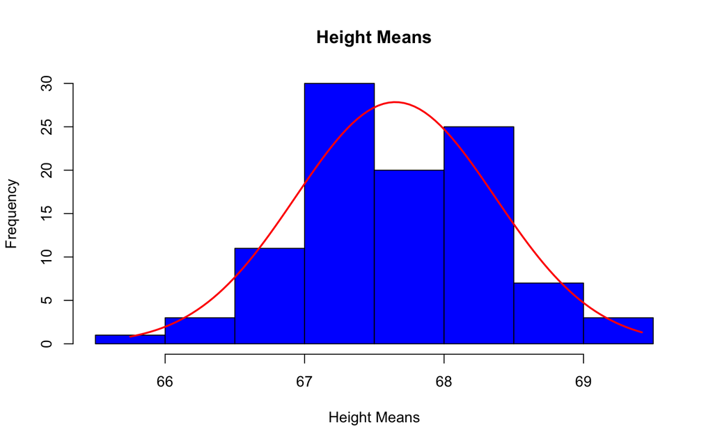

```r
# Plot the distributions using the function created in Question 3
plot_hist_and_norm(height_means, "Height Means", height_means_sd)
```

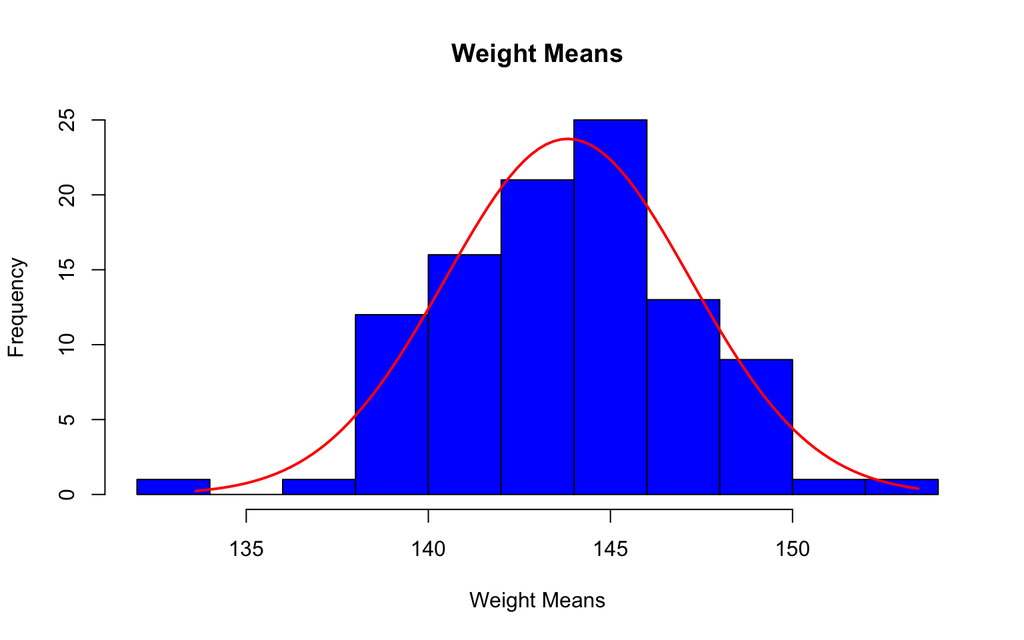

```r
plot_hist_and_norm(weight_means, "Weight Means", weight_means_sd)
```

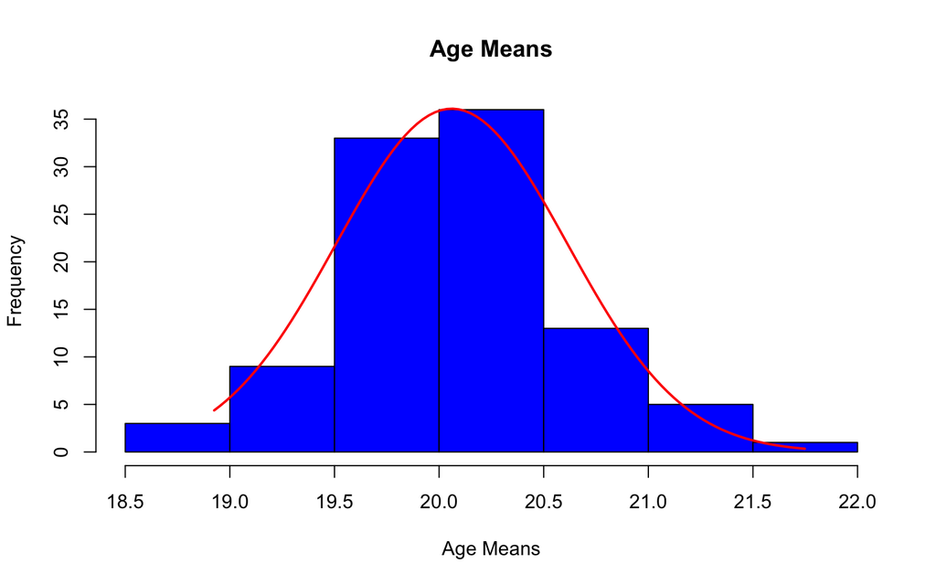

```r
plot_hist_and_norm(age_means, "Age Means", age_means_sd)
```

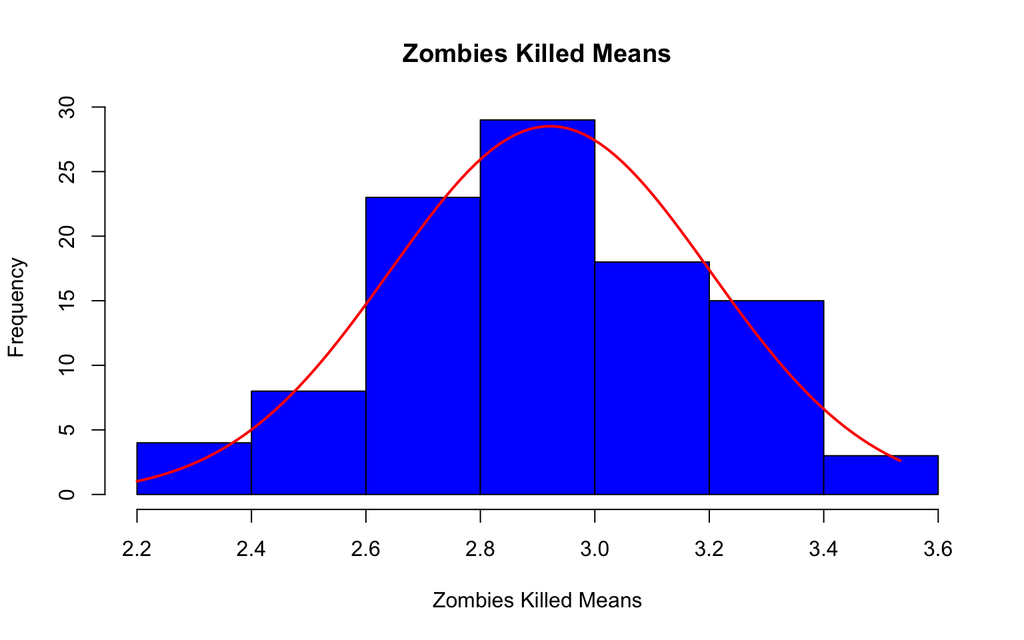

```r
plot_hist_and_norm(zombies_killed_means, "Zombies Killed Means", zombies_killed_means_sd)
```

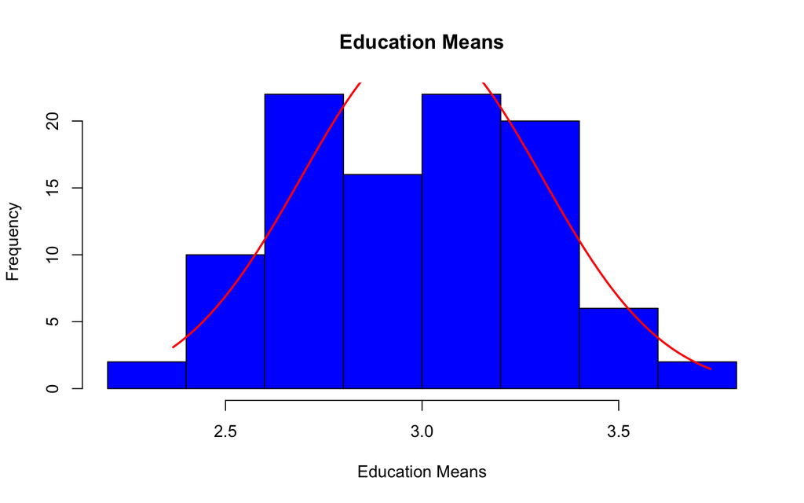

```r
plot_hist_and_norm(education_yrs_means, "Education Means", education_yrs_means_sd)
```

The sampling distributions all look normally distributed. For the previously not-normally distributed, it looks like after sampling the distribution looks more normal.

*Jess’s comments: You did AMAZING, Ritika! P.S. Don’t forget to include your homework challenges/ reflection.*

## Reflection

**When I was coding:**

*3 things were difficult:*  
1) The code felt super clunky at times, I felt like I wasn’t doing things as efficiently as possible so I spent a lot of time trying to make my code easy to follow  
2) I am still not having the best time graphing (especially the ggplot)! Practice is making it better though!  
3) I was trying to find a best fit plot for question 4 (e.g. Poission), but I had a hard time doing that!

**When I was Peer Commentating:**

*2 things you liked in your peers code:*  
1) My peer commented their code very well, from a reader perspective it was very easy to understand  
2) My peer plotted the normal and QQ plots again for the last question–something I missed but I think was helpful!

*1 thing that could use improvement:*  
1) Honestly I thought my peers code was great! As someone who had coded for a long time, I felt like my partners code was very easy to follow and intuitive! I thought he did an amazing job!